# Ebullition add-on - for water, saturated soil and flooded vegetation

Jonathan Gewirtzman

2026-09-24

Most chamber users (unsaturated surfaces) never meet ebullition and never need this vignette: the core path of `fluxqc` (`goFlux -> best.flux -> flag_detection -> qc_screens`, wrapped by `process_fluxes()`) does not call any of the code below. Over water, saturated peat or flooded vegetation, bubbles add abrupt step-ups to the smooth diffusive rise, and one linear or Hutchinson-Mosier fit through both components gives a number that is neither.

**Since goFlux 0.3.0 this is goFlux’s job.** Camille Minaudo added `goAquaFlux()` (with the internal `find.bubbles()` and `flux.plot.aqua()`): bubbling events are detected per closure from the rolling dispersion of the concentration series with an adaptive median + k x MAD threshold, each event’s step magnitude is estimated by a local step regression that separates the step from the diffusive trend and from the transient peak and re-equilibration that follow a bubble (goFlux 0.4.0), the diffusive flux is fitted with goFlux’s own model selection on the bubble-free part of the trace, and the ebullitive flux comes from the summed step magnitudes. `fluxqc` therefore no longer implements its own detector: the add-on is a thin adapter, `detect_ebullition()`, that forwards a click.peak2-style table to `goAquaFlux()` and appends the result to the flux table when `process_fluxes(ebullition = "flag" | "split")` is used. Despite its name, `goAquaFlux()` needs only `Vtot`, `Area`, `Pcham`, `Tcham` (and `Etime`, `flag`), so it applies to any bubbling surface.

## A real closure with a bubble burst

```r
library(fluxqc)
ex <- fluxqc_examples(c("ebullition_floating", "emission_stem_semirigid"))
both <- ex$data
ex$aux[, c("UniqueID", "obs.length", "Area", "Vtot", "Tcham", "analyzer")]
```

```
#>                  UniqueID obs.length   Area   Vtot Tcham              analyzer
#> 1     ebullition_floating        276  324.3 4.3180 28.72        ABB/LGR GLA131
#> 2 emission_stem_semirigid        600 4254.1 7.0827 26.02 ABB/LGR UGGA (GLA131)
```

```r
e <- both[both$UniqueID == "ebullition_floating", ]
```

## Detection and partition with goAquaFlux

```r
invisible(capture.output(eb <- suppressWarnings(detect_ebullition(both, "CH4dry_ppb"))))
eb$summary
```

```
#>                  UniqueID n_events total_ebullitive first_bubble_time flux_diffusive
#> 1     ebullition_floating        1             1089                23             NA
#> 2 emission_stem_semirigid        0                0                NA        0.25371
#>   SE_diffusive n_obs_diffusive flux_ebullitive SE_ebullitive flux_total  SE_total
#> 1           NA              24          21.077      0.048108         NA        NA
#> 2    0.0014338             766           0.000      0.000000    0.25371 0.0014338
```

```r
eb$events[, c("UniqueID", "start", "end", "magnitude", "SE", "slope", "n_used", "overshoot")]
```

```
#>              UniqueID start end magnitude     SE  slope n_used overshoot
#> 1 ebullition_floating    23  63      1089 2.4855 3.9435    152         0
```

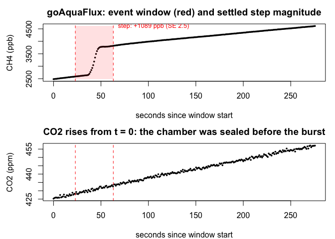

```r
ev <- eb$events
op <- par(mfrow = c(2, 1), mar = c(4, 4.5, 2.5, 1))
plot(e$Etime, e$CH4dry_ppb, pch = 16, cex = 0.5, type = "b", xlab = "seconds since window start",
     ylab = "CH4 (ppb)", main = "goAquaFlux: event window (red) and settled step magnitude")
rect(ev$start, min(e$CH4dry_ppb), ev$end, max(e$CH4dry_ppb), col = rgb(1, 0, 0, 0.12), border = NA)
abline(v = c(ev$start, ev$end), col = "red", lty = 2)
text(ev$end, max(e$CH4dry_ppb), sprintf("step: +%.0f ppb (SE %.1f)", ev$magnitude, ev$SE), pos = 4, col = "red", cex = 0.8)
plot(e$Etime, e$CO2dry_ppm, pch = 16, cex = 0.5, type = "b", xlab = "seconds since window start",
     ylab = "CO2 (ppm)", main = "CO2 rises from t = 0: the chamber was sealed before the burst")
abline(v = c(ev$start, ev$end), col = "red", lty = 2)
```

```r
par(op)
```

`goAquaFlux()` finds the one event (high-dispersion window 23-63 s) and estimates a settled step of 1089 ppb. It reports an ebullitive flux, but `flux_diffusive` and `flux_total` are `NA` for this closure: goAquaFlux fits the diffusive term on the observations *before the first bubble*, and here the burst comes after only ~23 s, too few points. That is a property of the closure (an early burst), not of the method; for the clean closure the partition returns the whole-trace flux with zero ebullition. `goFlux::flux.plot.aqua()` draws goFlux’s own diagnostic plot for such results.

## Through `process_fluxes()`

The add-on is an option of the pipeline, not a separate path. `"flag"` keeps the whole-trace `best.flux` and records the events; `"split"` additionally appends goFlux’s `flux_diffusive`, `flux_ebullitive`, `flux_total` (with SEs), `n_obs_diffusive`, `first_bubble_time` and `ebullition_method = "goAquaFlux"`. goFlux’s own columns (`best.flux`, `MDF`, …) are never modified. Per-closure control comes from `ebullition_ids` or a logical `ebullition` column in the auxfile, so the closures known to bubble can be partitioned while the rest of the same call run the core path.

```r
aux <- data.frame(UniqueID = c("emission_stem_semirigid", "ebullition_floating"), ebullition = c(FALSE, TRUE))
invisible(capture.output(       # goFlux's progress bar is captured
  res <- suppressWarnings(process_fluxes(both, aux = aux, gastype = "CH4dry_ppb",
                       qc = list(c0 = TRUE, convex = TRUE),
                       ebullition = "split"))))
res
```

```
#> fluxqc result: 2 closures, CH4dry_ppb
#>   MDF_emp: wassmann | mad | 0.95 | detected: 2 | qc_any: 0
#>   ebullition add-on: split ( goAquaFlux , 1 events )
```

```r
res$fluxes[, c("UniqueID", "ebullition_handling", "best.flux", "flux_diffusive", "flux_ebullitive",
               "flux_total", "n_ebullition_events", "first_bubble_time", "MDF_emp", "det_class_emp")]
```

```
#>                  UniqueID ebullition_handling best.flux flux_diffusive flux_ebullitive
#> 1     ebullition_floating               split  36.54058             NA          21.077
#> 2 emission_stem_semirigid                none   0.25372             NA           0.000
#>   flux_total n_ebullition_events first_bubble_time   MDF_emp det_class_emp
#> 1         NA                   1                23 0.0920464      emission
#> 2         NA                   0                NA 0.0041864      emission
```

```r
res$events[, c("UniqueID", "start", "end", "magnitude", "SE")]
```

```
#>              UniqueID start end magnitude     SE
#> 1 ebullition_floating    23  63      1089 2.4855
```

`write_outputs(res, dir)` then adds `ebullition_events.csv` (goFlux’s bubble table) next to `fluxes.csv` and `settings.json`.

## How other tools handle ebullition

Checked from the sources or manuals named; “not verified” marks claims that could not be checked.

[output not shown]

## Provenance and citation etiquette

`fluxqc`’s add-on contains no detection code of its own: all detection and partition is `goFlux::goAquaFlux()`, written by Camille Minaudo for goFlux 0.3.0-0.4.0. The earlier fluxqc implementations (a Hoffmann-style IQR fence filter, a fixed threshold and a running-variance method, none of which copied code from the Hoffmann Zenodo script or fluxCH4) were removed as duplicates. If you publish results obtained with the add-on, cite goFlux (Rheault, Christiansen & Larsen 2024, JOSS 9(96), 6393, doi:10.21105/joss.06393) and its aquatic partition (goFlux >= 0.3.0, C. Minaudo; see the goFlux changelog and package citation) alongside `citation("fluxqc")`.

## Limitations

Inherited from `goAquaFlux()`: the diffusive term needs enough bubble-free observations before the first event; analyzer artefacts (pressure transients, breaths on an inlet, valve switches) can look like bubbles; and the ebullitive rate assumes the bubbles caught in a 5-10 min closure represent the sampling period, which for episodic ebullition is rarely true. Review `events` against the traces (and `flux.plot.aqua()`) before reporting.